# Online Tutorial on `Regression Modeling with Actuarial and Financial Applications`

## 4.4 Unusual observations

In this section, you learn how to:

- Compare and contrast three alternative definitions of a standardized residual
- Evaluate three alternative options for dealing with outliers
- Assess the impact of a high leverage observation
- Evaluate options for dealing with high leverage observations
- Describe the notion of influence and Cook’s Distance for quantifying influence

### 4.4.1 Video

[interactive chart not shown]

#### Video Overhead Details

Hide

### A Details. Unusual observations

- Regression coefficients can be expressed as (matrix) weighted averages of outcomes
  - Averages, even weighted averages can be strongly influenced by unusual observations
- Observations may be unusual in the *y* direction or in the *X* space
- For unusual in the *y* direction, we use a residual $e = y - \hat{y}$
  - By subtracting the fitted value $\hat{y}$, we look to the *y* distance from the regression plane
  - In this way, we “control” for values of explanatory variables

Hide

### B Details. Standardized residuals

We standardize residuals so that we can focus on relationships of interest and achieve carry-over of experience from one data set to another.

Three commonly used definitions of standardize residuals are:

$$\text{(a) }\frac{e_i}{s}, \ \ \ \text{ (b) }\frac{e_i}{s\sqrt{1-h_{ii}}}, \ \ \
\text{(c)}\frac{e_i}{s_{(i)}\sqrt{1-h_{ii}}}.$$

- First choice is simple
- Second choice, from theory, $\mathrm{Var}(e_i)=\sigma ^{2}(1-h_{ii}).$ Here, $h_{ii}$ is the $i$th *leverage* (defined later).
- Third choice is termed “studentized residuals”. Idea: numerator is independent of the denominator.

Hide

### C Details. Outlier - an unusal standardized residual

- An *outlier* is an observation that is not well fit by the model; these are observations where the residual is unusually large.
- Unusual means what? Many packages mark a point if the |standardized residual| > 2.
- Options for handling outliers
  - Ignore them in the analysis but be sure to discuss their effects.
  - Delete them from the data set (but be sure to discuss their effects).
  - Create a binary variable to indicator their presence. (This will increase your $R^2$!)

Hide

### D Details. High leverage points

- A high leverage point is an observation that is “far away” in the $x$-space from others.
- One can get a feel for high leverage observations by looking a summary statistics (mins, maxs) for each explanatory variable.
- Options for dealing with high leverage points are comparable to outliers, we can ignore their effects, delete them, or mark them with a binary indicator variable.

Hide

### E Details. High leverage point graph

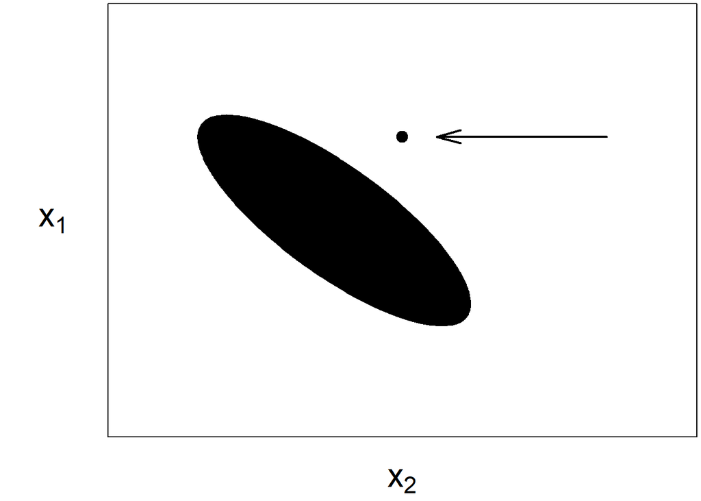

```r
library(cluster)
#library(MASS)
par(mar=c(3.2,5.4,.2,.2))
plot(1,5,type="p",pch=19,cex=1.5,xlab="",ylab="",cex.lab=1.5,xaxt="n",yaxt="n",xlim=c(-3,5),ylim=c(-12,12))
mtext(expression(x[2]), side=1,line=2, cex=2.0)
mtext(expression(x[1]), side=2, line=2, las=2, cex=2.0)
arrows(1.5,5,4,5,code=1,lwd=2,angle=15,length=0.25)
xycov<-matrix(c(2, -5,-5, 20),nrow=2,ncol=2)
xyloc<-matrix(c(0, 0),nrow=1,ncol=2)
polygon(ellipsoidPoints(xycov, d2 = 2, loc=xyloc),col="black")
```

Hide

### F Details. Leverage

- Using matrix algebra, one can express the *i*th fitted value as a linear combination of observations

$$\hat{y}_{i} = h_{i1} y_{1} + \cdots +h_{ii}y_{i}+\cdots+h_{in}y_{n}.$$

- The term $h_{ii}$ is known as the *i*th leverage
  - The larger the value of $h_{ii}$, the greater the effect of the *i*th observation $y_i$ on the *i*th fitted value $\hat{y}_i$.
  - Statistical routines have values of the leverage coded, so computing this quantity. The key thing to know is that $h_{ii}$ is based solely on the explanatory variables. If you change the $y$ values, the leverage does not change.
  - As a commonly used rule of thumb, a leverage is deemed to be “unusual” if its value exceeds three times the average (= number of regression coefficients divided by the number of observations.)

### 4.4.2 Exercise. Outlier example

In chapter 2, we consider a fictitious data set of 19 “base” points plus three different types of unusual points. In this exercise, we consider the effect of one unusal point, “C”, this both an outlier (unusual in the “y” direction) and a high leverage point (usual in the x-space). The data have been pre-loaded in the dataframe `outlrC`.

**Instructions**

- Fit a basic linear regression model of `y` on `x` and store the result in an object.
- Use the function [rstandard()](https://www.rdocumentation.org/packages/stats/versions/3.5.0/topics/influence.measures) to extract the standardized residuals from the fitted regression model object and summarize them.
- Use the function [hatvalues()](https://www.rdocumentation.org/packages/stats/versions/3.5.0/topics/influence.measures) to extract the leverages from the model fitted and summarize them.
- Plot the standardized residuals versus the leverages to see the relationship between these two measures that calibrate how unusual an observation is.

### 4.4.3 Exercise. High leverage and risk manager survey

**Assignment Text**

In a prior exercise, we fit a regression model of `logcost` on `logsize`, `indcost` and a squared version of `indcost`. This model is summarized in the object `mlr_survey2`. In this exercise, we examine the robustness of the model to unusual observations.

**Instructions**

- Use the `R` functions [rstandard()](https://www.rdocumentation.org/packages/stats/versions/3.5.0/topics/influence.measures) and [hatvalues()](https://www.rdocumentation.org/packages/stats/versions/3.5.0/topics/influence.measures) to extract the standardized residuals and leverages from the model fitted. Summarize the distributions graphically.
- You will see that there are two observations where the leverages are high, numbers 10 and 16. On looking at the dataset, these turn out to be observations in a high risk industry. Create a histogram of the variable `indcost` to corroborate this.
- Re-run the regression omitting observations 10 and 16. Summarize this regression and the regression in the object `mlr_survey2`, noting differences in the coefficients.

## 4.5 Collinearity

In this section, you learn how to:

- Define collinearity and describe its potential impact on regression inference
- Define a variance inflation factor and describe its effect on a regression coefficients standard error
- Describe rules of thumb for assessing collinearity and options for model reformulation in the presence of severe collinearity
- Compare and contrast effects of leverage and collinearity

### 4.5.1 Video

[interactive chart not shown]

#### Video Overhead Details

Hide

### A Details. Collinearity

- *Collinearity*, or *multicollinearity*, occurs when one explanatory variable is, or nearly is, a linear combination of the other explanatory variables.
  - Useful to think of the explanatory variables as being highly correlated with one another.
- Collinearity neither precludes us from getting good fits nor from making predictions of new observations.
  - Estimates of error variances and, therefore, tests of model adequacy, are still reliable.
- In cases of serious collinearity, standard errors of individual regression coefficients can be large.
  - With large standard errors, individual regression coefficients may not be meaningful.
  - Because a large standard error means that the corresponding *t*-ratio is small, it is difficult to detect the importance of a variable.

Hide

### B Details. Quantifying collinearity

A common way to quantify collinearity is through the *variance inflation factor (VIF)*.

- Suppose that the set of explanatory variables is labeled $x_{1},x_{2},\dots,x_{k}$.
- Run the regression using $x_{j}$ as the “outcome” and the other $x$’s as the explanatory variables.
- Denote the coefficient of determination from this regression by $R_j^2$.
- Define the variance inflation factor

$$VIF_{j}=\frac{1}{1-R_{j}^{2}},\ \ \ \text{ for } j = 1,2,\ldots, k.$$

Hide

### C Details. Options for handling collinearity

- Rule of thumb: When $VIF_{j}$ exceeds 10 (which is equivalent to $R_{j}^{2}>90\%$), we say that severe collinearity exists. This may signal is a need for action.
- Recode the variables by “centering” - that is, subtract the mean and divide by the standard deviation.
- Ignore the collinearity in the analysis but comment on it in the interpretation. Probably the most common approach.
- Replace one or more variables by auxiliary variables or transformed versions.
- Remove one or more variables. Easy. Which One? is hard.
  - Use interpretation. Which variable(s) do you feel most comfortable with?
  - Use automatic variable selection procedures to suggest a model.

### 4.5.2 Exercise. Collinearity and term life

**Assignment Text** We have seen that adding an explanatory variable $x^2$ to a model is sometimes helpful even though it is perfectly related to $x$ (such as through the function $f(x)=x^2$). But, for some data sets, higher order polynomials and interactions can be approximately linearly related (depending on the range of the data).

This exercise returns to our term life data set `Term1` (preloaded) and demonstrates that collinearity can be severe when introducing interaction terms.

**Instructions**

- Fit a MLR model of `logface` on explantory variables `education`, `numhh` and `logincome`
- Use the function [vif()](https://www.rdocumentation.org/packages/car/versions/3.0-0/topics/vif) from the `car` package (preloaded) to calculate variance inflation factors.
- Fit and summarize a MLR model of `logface` on explantory variables `education` , `numhh` and `logincome` with an interaction between `numhh` and `logincome`, then extract variance inflation factors.

**Hint.** If the `car` package is not available to you, then you could calculate vifs using the [lm()] function, treating each variable separately. For example

`1/(1-summary(lm(education ~ numhh + logincome, data = Term1))$r.squared)`

gives the `education` vif.

## 4.6 Selection criteria

In this section, you learn how to:

- Summarize a regression fit using alternative goodness of fit measures
- Validate a model using in-sample and out-of-sample data to mitigate issues of data-snooping
- Compare and contrast *SSPE* and *PRESS* statistics for model validation

### 4.6.1 Video

[interactive chart not shown]

#### Video Overhead Details

Hide

### A Details. Goodness of fit

- Criteria that measure the proximity of the fitted model and realized data are known as *goodness of fit* statistics.
- Basic examples include:
  - the coefficient of determination $(R^{2})$,
  - an adjusted version $(R_{a}^{2})$,
  - the size of the typical error $(s)$, and
  - $t$-ratios for each regression coefficient.

Hide

### A Details. Goodness of fit

A general measure is *Akaike’s Information Criterion*, defined as

$$AIC = -2 \times (fitted~log~likelihood) + 2 \times
(number~of~parameters)$$

- For model comparison, the smaller the $AIC,$ the better is the fit.
- This measures balances the fit (in the first part) with a penalty for complexity (in the second part)
- It is a general measure - for linear regression, it reduces to

$$AIC = n \ln (s^2) + n \ln (2 \pi) +n +k + 3 .$$

- So, selecting a model to minimize $s$ or $s^2$ is equivalent to model selection based on minimizing $AIC$ (same *k*).

Hide

### C Details. Out of sample validation

- When you choose a model to minimize $s$ or $AIC$, it is based on how well the model fits the data at hand, or the *model development*, or *training*, data
- As we have seen, this approach is susceptible to overfitting.
- A better approach is to validate the model on a *model validation*, or *test* data set, held out for this purpose.

Hide

### D Details. Out of sample validation procedure

- 1. Using the model development subsample, fit a candidate model.
- 2. Using the Step (ii) model and the explanatory variables from the validation subsample, “predict” the dependent variables in the validation subsample, $\hat{y}_i$, where $i=n_{1}+1,...,n_{1}+n_{2}$.
- 3. Calc the *sum of absolute prediction errors**

$$SAPE=\sum_{i=n_{1}+1}^{n_{1}+n_{2}} |y_{i}-\hat{y}_{i}| .$$

Repeat Steps (i) through (iii) for each candidate model. Choose the model with the smallest *SAPE*.

Hide

### E Details. Cross - validation

- With out-of-sample validation, the statistic depends on a random split between in-sample and out-of-sample data (a problem for data sets that are not large)
- Alternatively, one may use *cross-validation*
  - Use a random mechanism to split the data into *k* subsets, (e.g., 5-10)
  - Use the first *k-1* subsamples to estimate model parameters. Then, “predict” the outcomes for the *k*th subsample and use *SAE* to summarize the fit
  - Repeat this by holding out each of the *k* sub-samples, summarizing with a cumulative *SAE*.
- Repeat these steps for several candidate models.
  - Choose the model with the lowest cumulative *SAE* statistic.

### 4.6.2 Exercise. Cross-validation and term life

**Assignment Text**

Here is some sample code to give you a better feel for cross-validation.

The first part of the randomly re-orders (“shuffles”) the data. It also identifies explanatory variables `explvars`.

The function starts by pulling out only the needed data into `cvdata`. Then, for each subsample, a model is fit based on all the data except for the subsample, in `train_mlr` with the subsample in `test`. This is repeated for each subsample, then results are summarized.

###### **Show Code**

```
# Randomly re-order data - "shuffle it"
n <- nrow(Term1)
set.seed(12347)
shuffled_Term1 <- Term1[sample(n), ]
explvars <- c("education", "numhh", "logincome")

## Cross - Validation
crossvalfct <- function(explvars){
  cvdata   <- shuffled_Term1[, c("logface", explvars)]
  crossval <- 0
  k <- 5
  for (i in 1:k) {
    indices <- (((i-1) * round((1/k)*nrow(cvdata))) + 1):((i*round((1/k) * nrow(cvdata))))
    # Exclude them from the train set
    train_mlr <- lm(logface ~ ., data = cvdata[-indices,])
    # Include them in the test set
    test  <- data.frame(cvdata[indices, explvars])
    names(test)  <- explvars
    predict_test <- exp(predict(train_mlr, test))
    # Compare predicted to held-out and summarize
    predict_err  <- exp(cvdata[indices, "logface"]) - predict_test
    crossval <- crossval + sum(abs(predict_err))
  }
  crossval/1000
}

crossvalfct(explvars)
```

**Instructions**

- Calculate the cross-validation statistic using only logarithmic income, `logincome`.
- Calculate the cross-validation statistic using `logincome`, `education` and `numhh`.
- Calculate the cross-validation statistic using `logincome`, `education`, `numhh` and `marstat`.

The best model has the lowest cross-validation statistic.

# 5 Interpreting Regression Results

**Chapter description**

A case study, on determining an individual’s characteristics that influence its health expenditures, illustrates the regression modeling process from start to finish. Subsequently, the chapter summarizes what we learn from the modeling process, underscoring the importance of variable selection.

## 5.1 Case study: MEPS health expenditures

### 5.1.1 Video

[interactive chart not shown]

#### Video Overhead Details

Hide

### A Details. MEPS health expenditures

This exercise considers data from the *Medical Expenditure Panel Survey* (MEPS), conducted by the U.S. Agency of Health Research and Quality. MEPS is a probability survey that provides nationally representative estimates of health care use, expenditures, sources of payment, and insurance coverage for the U.S. civilian population. This survey collects detailed information on individuals of each medical care episode by type of services including physician office visits, hospital emergency room visits, hospital outpatient visits, hospital inpatient stays, all other medical provider visits, and use of prescribed medicines. This detailed information allows one to develop models of health care utilization to predict future expenditures. You can learn more about MEPS at http://www.meps.ahrq.gov/mepsweb/.

We consider MEPS data from the panels 7 and 8 of 2003 that consists of 18,735 individuals between ages 18 and 65. From this sample, we took a random sample of 2,000 individuals that appear in the file `HealthExpend`. From this sample, there are 1,352 that had positive outpatient expenditures.

Our dependent variable is the amount of expenditures for outpatient visits, `expendop`. For MEPS, outpatient events include hospital outpatient department visits, office-based provider visits and emergency room visits excluding dental services. (Dental services, compared to other types of health care services, are more predictable and occur in a more regular basis.) Hospital stays with the same date of admission and discharge, known as “zero-night stays,” were included in outpatient counts and expenditures. (Payments associated with emergency room visits that immediately preceded an inpatient stay were included in the inpatient expenditures. Prescribed medicines that can be linked to hospital admissions were included in inpatient expenditures, not in outpatient utilization.)

Hide

### B Details. Overhead MEPS health expenditures

Data from the Medical Expenditure Panel Survey (MEPS), conducted by the U.S. Agency of Health Research and Quality (AHRQ).

- A probability survey that provides nationally representative estimates of health care use, expenditures, sources of payment, and insurance coverage for the U.S. civilian population.
- Collects detailed information on individuals of each medical care episode by type of services including
  - physician office visits,
  - hospital emergency room visits,
  - hospital outpatient visits,
  - hospital inpatient stays,
  - all other medical provider visits, and
  - use of prescribed medicines.
- This detailed information allows one to develop models of health care utilization to predict future expenditures.
- We consider MEPS data from the first panel of 2003 and take a random sample of *n* = 2, 000 individuals between ages 18 and 65.

Hide

### C Details. Outcome variable

Our dependent variable is expenditures for outpatient admissions.

- For MEPS, inpatient admissions include persons who were admitted to a hospital and stayed overnight.
- In contrast, outpatient events include hospital outpatient department visits, office-based provider visits and emergency room visits excluding dental services.
  - Hospital stays with the same date of admission and discharge, known as “zero-night stays,” were included in outpatient counts and expenditures.
  - Payments associated with emergency room visits that immediately preceded an inpatient stay were included in the inpatient expenditures.
  - Prescribed medicines that can be linked to hospital admissions were included in inpatient expenditures, not in outpatient utilization.

Hide

### D Details. Explanatory variables

$${\small \begin{array}{ll}
expendop & \text{Amounts of expenditures for outpatient visits} \\
gender & \text{Indicate gender of patient (=1 if female, =0 if male)} \\
age & \text{Age in years between 18 and 65 }\\
race & \text{Race of patient described as Asian, Black, Native, White and other} \\
region & \text{Region of patient described as WEST, NORTHEAST, MIDWEST and SOUTH} \\
educ & \text{Level of education received described by words (LHIGHSC, HIGHSCH and COLLEGE)} \\
phstat & \text{Self-rated physical health status described as EXCE, VGOO, GOOD, FAIR and POOR} \\
mpoor & \text{Self-rated mental health (=1 if poor or fair, =0 if good to excellent mental health)} \\
anylimit & \text{Any activity limitation (=1 if any functional/activity limitation, =0 if otherwise)} \\
income & \text{Income compared to poverty line described as POOR, NPOOR, LINCOME, MINCOME and HINCOME} \\
insure & \text{Insurance coverage (=1 if covered by public/private health insurance in any month of 1996, =0 otherwise)} \\
usc & \text{1 if dissatisfied with one's usual source of care} \\
unemploy & \text{Employment status of patients} \\
managedcare & \text{1 if enrolled in an HMO or gatekeeper plan} \\
\end{array}}$$

Hide

### E Details. Case study outline

The next series of exercises leads you through an analysis of the steps for understanding a complex data set. Because of the complexity of the data, in each step only a sample of procedures will be executed.

The outline consists of:

- Summary statistics
- Splitting the data into training and testing portions with initial model fits
- Selecting variables to be included in the model

### 5.1.2 Exercise. Summarizing data

**Assignment Text**

With a complex dataset, you will probably want to take a look at the structure of the data. You are already familiar with taking a [summary()] of a dataframe which provides summary statistics for many variables. You will see that several variables in this dataframe are categorical, or factor, variables. We can use the [table()](https://www.rdocumentation.org/packages/base/versions/3.5.0/topics/table) function to summarize them.

After getting a sense of the distributions of explanatory variables, we want to take a deeper dive into the distribution of the outcome variable, `expendop`. We will do this by comparing the histograms of the variable to that of its logarithmic version.

To examine relationships of the outcome variable visually, we look to scatterplots for continuous variables (such as `age`) and boxplots for categorical variables (such as `phstat`).

**Instructions**

- Examine the structure of the `meps` dataframe using the [str()](https://www.rdocumentation.org/packages/utils/versions/3.5.0/topics/str/) function. Also, get a [summary()] of the dataframe.
- Examine the distribution of the `race` variable using the [table()](https://www.rdocumentation.org/packages/base/versions/3.5.0/topics/table) function.
- Compare the expenditures distribution to its logarithmic version visually via histograms plotted next to another. `par(mfrow = c(1, 2))` is used to organize the plots you create.
- Examine the distribution of logarithmic expenditures in terms of levels of `phstat` visually using the [boxplot()](https://www.rdocumentation.org/packages/graphics/versions/3.5.0/topics/boxplot/) function.
- Examine the relationship of age versus logarithmic expenditures using a scatter plot. Superimpose a local fitting line using the [lines()](https://www.rdocumentation.org/packages/graphics/versions/3.5.0/topics/lines) and [lowess()](https://www.rdocumentation.org/packages/stats/versions/3.5.0/topics/lowess) functions.

### 5.1.3 Exercise. Fit a benchmark multiple linear regression model

**Assignment Text**

As part of the pre-processing for the model fitting, we will split the data into training and test subsamples. For this exercise, we use a 75/25 split although other choices are certainly suitable. Some analysts prefer to do this splitting before looking at the data. Another approach, adopted here, is that the final report typically contains summary statistcs of the entire data set and so it makes sense to do so when examining summary statistics.

We start by fitting a benchmark model. It is common to use all available explanatory variables with the outcome on the original scale and so we use this as our benchmark model. This exercise shows that when you [plot()](https://www.rdocumentation.org/packages/graphics/versions/3.5.0/topics/plot) a fitted linear regression model in `R`, the result provides four graphs that you have seen before. These can be useful for identifying an appropriate model.

**Instructions**

- Randomly split the data into a training and a testing data sets. Use 75% for the training, 25% for the testing.
- Fit a full model using `expendop` as the outcome and all explanatory variables. Summarize the results of this model fitting.
- You can [plot()](https://www.rdocumentation.org/packages/graphics/versions/3.5.0/topics/plot) the fitted model to view several diagnostic plots. These plots provide evidence that expenditures may not be the best scale for linear regression.
- Fit a full model using `logexpend` as the outcome and all explanatory variables and summarize the fit. Use the plot() function for evidence that this variable is more suited for linear regression methods than expenditures on the original scale.

**Hint.** A `plot` of a regression object such as plot(mlr) provides four diagnostic plots. These can be organized as a 2 by 2 array using `par(mfrow = c(2, 2))`.

### 5.1.4 Exercise. Variable selection

**Assignment Text**

Modeling building can be approached using a “ground-up” strategy, where the analyst introduces a variable, examines residuls from a regression fit, and then seeks to understand the relationship between these residuals and other available variables so that these variables might be added to the model.

Another approach is a “top-down” strategy where all available variables are entered into a model and unnecessary variables are pruned from the model. Both approaches are helpful when using data to specify models. This exercise illustrates the latter approach, using the [step()] function to help narrow our search for the best fitting model.

**Instructions**

From our prior work, the training dataframe `train_meps` has already been loaded in. A multiple linear regression model fit object `meps_mlr2` is available that summarizes a fit of `logexpend` as the outcome variable using all 13 explanatory variables.

- Use the [step()](https://www.rdocumentation.org/packages/stats/versions/3.5.0/topics/step) function function to drop unnecessary variables from the full fitted model summarized in the object `meps_mlr2` and summarize this recommended model.
- As an alternative, use the explanatory variables in the recommended model and add the varibles `phstat`. Summarize the fit and note that statistical significance of the new variable.
- You have been reminded by your boss that use of the variable `gender` is unsuitable for actuarial pricing purposes. As an another alternative, drop `gender` from the recommended model (still keeping `phstat`). Note the statistical significance of the variable `usc`with this fitted model.

### 5.1.5 Exercise. Model comparisons using cross-validation

**Assignment Text**

To compare alternative models, you decide to utilize cross-validation. For this exercise, you split the training sample into six subsamples of approximately equal size.

In the sample code, the cross-validation procedure has been summarized into a function that you can call. The input to the function is a list of variables that you select as your model explanatory variables. With this function, you can readily test several candidate models.

**Instructions**

- Run the cross validation (`crossvalfct`) function using the explanatory variables suggested by the stepwise function.
- Run the function again but adding the `mpoor` variable
- Run the function again but omitting the `gender` variable

Note which model is suggested by the cross validation function.

### 5.1.6 Exercise. Out of sample validation

**Assignment Text**

From our prior work, the training `train_meps` and test `test_meps` dataframes have already been loaded in. We think our best model is based on logarithmic expenditures as the outcome and the following explanatory variables:

```
explvars3 <- c("gender", "age", "phstat", "anylimit", "insure", "mpoor")
```

We will compare this to a benchmark model that is based on expenditures as the outcome and all 13 explanatory variables

```
explvars4 <- c(explvars3, "race", "income", "region", "educ", "unemploy", "managedcare", "usc")
```

The comparisons will be based on expenditures in dollars using the held-out validation sample.

**Instructions**

- Use the training sample to fit a linear model with `logexpend` and explanatory variables listed in `explvars3`
- Predict expenditures (not logged) for the test data and summarize the fit using the sum of absolute prediction errors.
- Use the training sample to fit a benchmark linear model with `expendop` and explanatory variables listed in `explvars4`
- Predict expenditures for the test data and summarize the fit for the benchmark model using the sum of absolute prediction errors.
- Compare the predictions of the models graphically.

## 5.2 What the modeling procedure tells us

In this section, you learn how to:

- Interpret individual effects, based on their substantive and statistical significance
- Describe other purposes of regression modeling, including regression function for pricing, benchmarking studies, and predicting future observations.

### 5.2.1 Video

[interactive chart not shown]

#### Video Overhead Details

Hide

### A Details. Interpreting individual effects

- Substantive Effect
  - Does a 1 unit change in $x$ imply an economically meaningful change in $y$?
  - Example: Looking at urban and rural claims experience, is there a big enough difference to warrant differentiating prices by location?
- Statistical Significance
  - We have standards for deciding whether or not a variable is statistically significant.
  - A “statistically significant effect” is the result of a regression coefficient that is large relative to its standard error.
- Statistical significance is driven by
  - precision of $s$,
  - collinearity ($VIF$) and
  - sample size
- **Causal Effects**
  - If we change $x$, would $y$ change?

Hide

### B Details. Other Interpretations

- Regression function and pricing
  - The regression function is $\mathrm{E~}y = \beta_0 + \beta_1 x_1 + \cdots +\beta _k x_k$.
  - Think about expected claims as our baseline price for short-term insurance coverages.
- Benchmarking studies
  - In studies of CEO’s salaries, who is making a lot (or a little), controlled for industry, years of experience and so forth?
  - In studies of medical claims, who are the high-cost patients?
- Prediction
  - A new patient comes in with a given set of characteristics, what can I say about his or her future medical claims?

**MC Exercise. Which of the following are not important when interpreting the effects of individual variables?**

Substantive significance  
Statistical significance  
The amount of effort that it took to gather the data and do the analysis  
Role of causality

**MC Exercise. Which of the following is not a potential explanation for the lack of statistical significance of an explanatory variable?**

Large variation of the disturbance term  
High collinearity, so that the variable may be confounded with other variables  
The coefficient of determination, $R^2$, is not sufficiently large

**MC Exercise. Which of the following is not an important purpose of regression modeling?**

Pricing of risks such as insurance contracts  
Benchmarking studies, to compare an observation to others  
Prediction  
Keeping a computer occupied with work

## 5.3 The importance of variable selection

In this section, you learn how to:

- Describe the bias that can occur when omitting important variables
- Describe the principle of parsimony and reasons for adopting this approach

### 5.3.1 Video

[interactive chart not shown]

#### Video Overhead Details

Hide

### A Details. The importance of variable selection

- With too many or too few variables, $s$ is too large an estimate of $\sigma$.
  - Prediction intervals are too large
  - Standard errors for the partial slopes are too large
- With too few or incorrect variables, we produce biased estimates of the slopes $\beta$. Thus, our predictions are biased and hence inaccurate.

Hide

### B Details. Example. Regression using one explanatory variable

- **Too Many Variables**
  - The “true” model is $y_i = \beta_0+ \varepsilon_i$
  - We mistakenly use $y_i = \beta_0+ \beta_1 x_i^* + \varepsilon_i$
  - The prediction at a generic level $x$ is $b_0^* + b_1^* x$.
  - It is not to hard to confirm that $Bias = \mathrm{E} (b_0^* + b_1^* x) - \mathrm{E } y= 0$.
- **Too Few Variables**
  - The “true” model is $y_i = \beta_0 + \beta_1 x_i + \varepsilon_i$.
  - We mistakenly use $y_i = \beta_0^* \varepsilon_i$.
  - Under the true model, $\overline{y} = \beta_0 + \beta_1 \overline{x} + \overline{\varepsilon}$
  - Thus, the bias is

$$Bias = \text{E }\bar{y} - \text{E }(\beta_0 + \beta_1 x + \varepsilon) \\
= \text{E }(\beta_0 + \beta_1 \bar{x}+\bar{\varepsilon})-(\beta_0+\beta_1 x)=\beta_1 (\bar{x}-x).$$

There is a persistent, long-term error in omitting the explanatory variable $x$.

Hide

### C Details. Principle of parsimony

- The principle of parsimony, also known as *Occam’s Razor*, states that when there are several possible explanations for a phenomenon, use the simplest.
  - A simpler explanation is easier to interpret.
  - Simpler models, also known as ``more parsimonious’’ models, often do well on fitting out-of-sample data
  - Extraneous variables can cause problems of collinearity, leading to difficulty in interpreting individual coefficients.
- In contrast, in a quote often attributed to Albert Einstein, we should use “the simplest model possible, but no simpler.”
  - Omitting important variables can lead to biased results, a potentially serious error.
  - Including extraneous variables decreases the degrees of freedom and increases the estimate of variability, typically of less concern in actuarial applications.

**MC Exercise. Which of the following is true about under- and over-fitting a model?**

When we over-fit a model, estimates of regression coefficients are over-biased as is $s^2$, the estimate of model variance $\sigma^2$.  
When we over-fit a model, estimates of regression coefficients remain unbiased whereas $s^2$, the estimate of model variance $\sigma^2$, is over-biased.  
When we over-fit a model, estimates of regression coefficients remain under-biased as is $s^2$, the estimate of model variance $\sigma^2$.  
When we under-fit a model, estimates of regression coefficients remain unbiased whereas $s^2$, the estimate of model variance $\sigma^2$, is over-biased.

**MC Exercise. Which of the following is not true of Occam’s Razor?**

When there are several possible explanations for a phenomenon, use the simplest one.  
Simpler models are easier to interpret.  
Variables can be statistically significant but practically unimportant.  
Simpler models often do better for predicting out-of-sample data